# Pendugaan Parameter, Diagnostik Model, dan Peramalan

Aisyah Nuruzzahra Tirtasuwanda

2023-09-30

## Packages

```r
library(ggplot2)
library(tsibble)
library(tseries)
library(MASS)
library(forecast)
library(TSA)
library(TTR)
library(aTSA)
library(graphics)
library(lmtest)
```

## Data Bangkitan

### Pembangkitan Data

```r
data <-rio::import("https://github.com/zahratirtasuwanda/prak-mpdw/raw/main/Pertemuan%201/Meta%20Stock%20-%20Sheet1%20(1).csv")
str(data)
```

```
## 'data.frame':    252 obs. of  2 variables:
##  $ Date: IDate, format: "2021-09-20" "2021-09-21" ...
##  $ Open: num  359 358 347 345 343 ...
```

```r
datameta <- data[1:250,]
datameta.ts<-ts(datameta)
```

# Membagi data menjadi data latih (80%) dan data uji (20%) dan jadikan time series

```r
train <- datameta[1:200,2]
test <- datameta[201:250,2]
train.ts <- ts(train, frequency = 6)
test.ts <- ts(test, frequency = )
```

# Eksplorasi

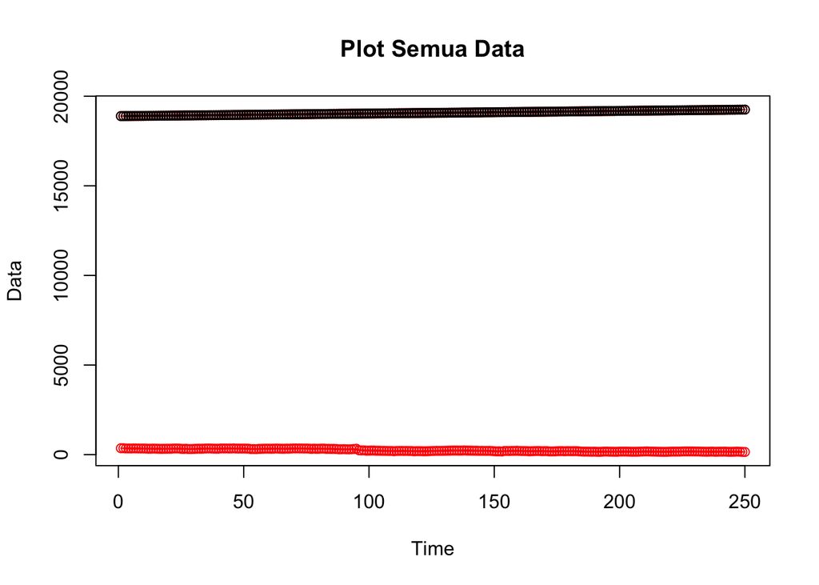

```r
# Data Full
ts.plot(datameta.ts, col="red",main="Plot Semua Data", type="o",xlab="Time",ylab="Data")
points(datameta.ts)
```

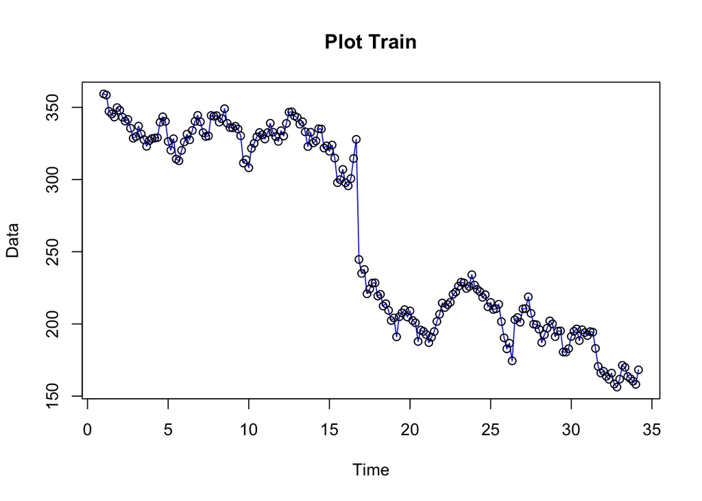

```r
# data latih
ts.plot(train.ts, col="blue",main="Plot Train", type="o",xlab="Time",ylab="Data")
points(train.ts)
```

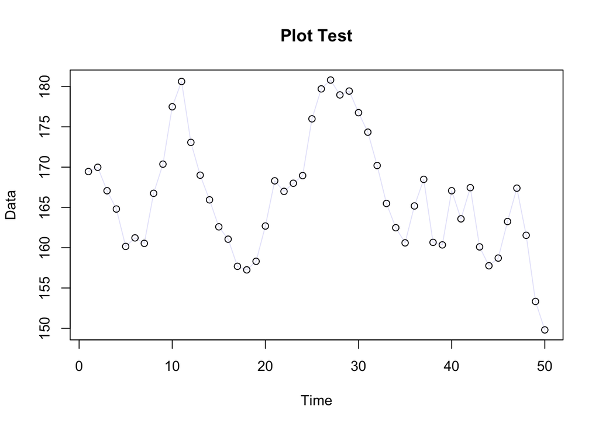

```r
# data uji
ts.plot(test.ts, col="lavender",main="Plot Test", type="o",xlab="Time",ylab="Data")
points(test.ts)
```

Dapat dilihat bahwa data deret waktu membentuk pola trend dan data tersebut tidak stasioner dalam rataan dan ragam.

# Check Stasioner

## Plot acf

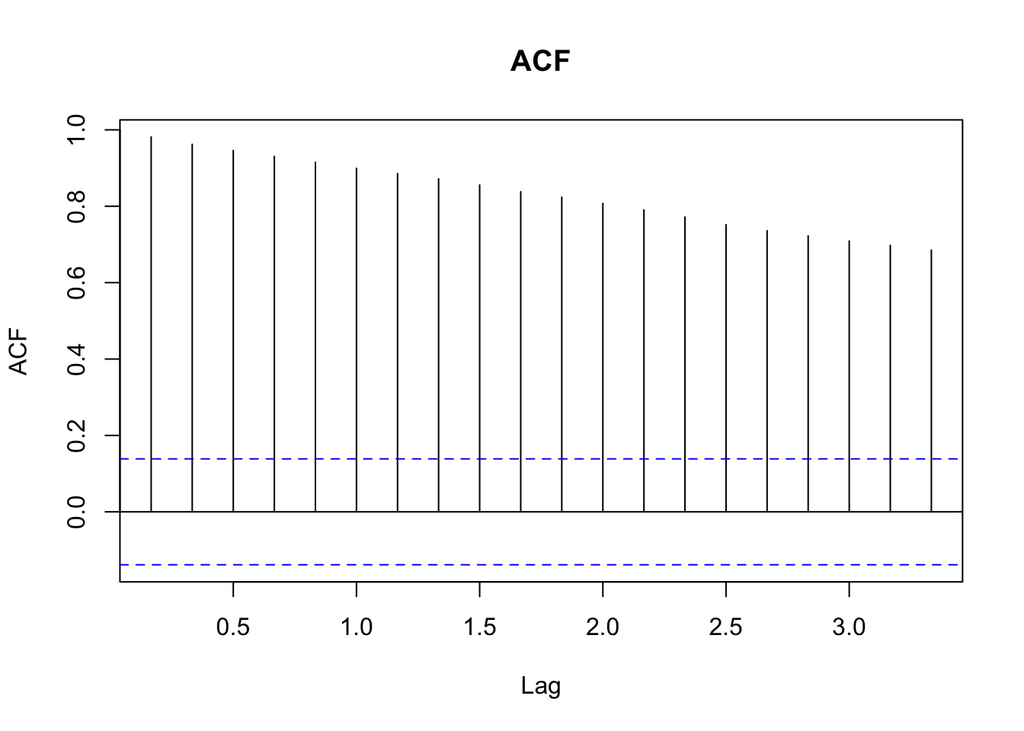

```r
acf(train.ts, main="ACF", lag.max=20)
```

Berdasarkan plot ACF pada data train, terlihat bahwa plot ACF pada data train menurun secara perlahan (tails off slowly) menandakan bahwa data train tersebut tidak stasioner dalam rataan.

## Uji ADF

```r
tseries::adf.test(train.ts)
```

```
##
##  Augmented Dickey-Fuller Test
##
## data:  train.ts
## Dickey-Fuller = -2.0512, Lag order = 5, p-value = 0.5547
## alternative hypothesis: stationary
```

$H_0$ : Data tidak stasioner dalam rataan

$H_1$ : Data stasioner dalam rataan

Berdasarkan uji ADF tersebut, didapat p-value sebesar 0.5547 yang lebih besar dari taraf nyata 5% sehingga tak tolak $H_0$ dan menandakan bahwa data tidak stasioner dalam rataan. Hal ini sesuai dengan hasil eksplorasi menggunakan plot time series dan plot ACF.

## Plot Box-Cox

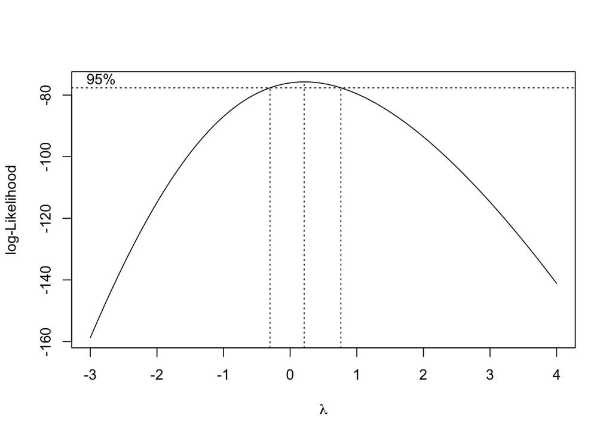

```r
index <- seq(1:200) #sebanyak row data
bc = boxcox(train.ts~index, lambda = seq(-3,4,by=0.01))
```

```r
#Nilai Rounded Lambda
lambda <- bc$x[which.max(bc$y)]
lambda
```

```
## [1] 0.21
```

```r
#SK
bc$x[bc$y > max(bc$y) - 1/2 * qchisq(.95,1)]
```

```
##   [1] -0.30 -0.29 -0.28 -0.27 -0.26 -0.25 -0.24 -0.23 -0.22 -0.21 -0.20 -0.19
##  [13] -0.18 -0.17 -0.16 -0.15 -0.14 -0.13 -0.12 -0.11 -0.10 -0.09 -0.08 -0.07
##  [25] -0.06 -0.05 -0.04 -0.03 -0.02 -0.01  0.00  0.01  0.02  0.03  0.04  0.05
##  [37]  0.06  0.07  0.08  0.09  0.10  0.11  0.12  0.13  0.14  0.15  0.16  0.17
##  [49]  0.18  0.19  0.20  0.21  0.22  0.23  0.24  0.25  0.26  0.27  0.28  0.29
##  [61]  0.30  0.31  0.32  0.33  0.34  0.35  0.36  0.37  0.38  0.39  0.40  0.41
##  [73]  0.42  0.43  0.44  0.45  0.46  0.47  0.48  0.49  0.50  0.51  0.52  0.53
##  [85]  0.54  0.55  0.56  0.57  0.58  0.59  0.60  0.61  0.62  0.63  0.64  0.65
##  [97]  0.66  0.67  0.68  0.69  0.70  0.71  0.72  0.73  0.74  0.75  0.76
```

# Penanganan Data Tidak Stasioner dalam Rataan

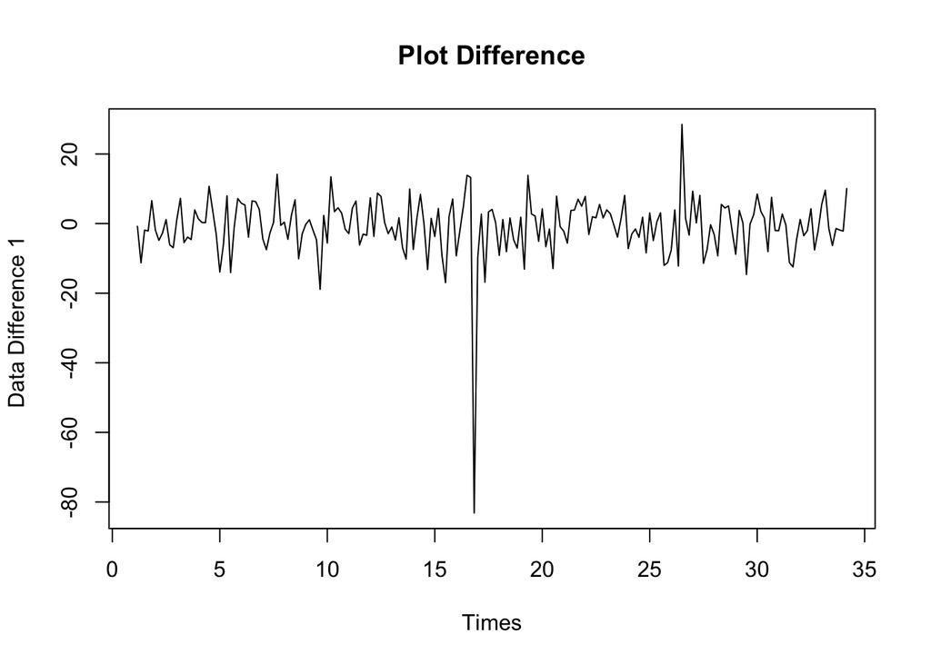

```r
train.diff<-diff(train.ts,differences = 1)
plot.ts(train.diff, lty=1, xlab="Times", ylab="Data Difference 1 ", main="Plot Difference")
```

Pada plot di atas terlihat bahwa data sudah stasioner dalam rataan ditandai dengan data bergerak pada nilai tengah.

## Plot ACF dan PACF Setelah Penanganan

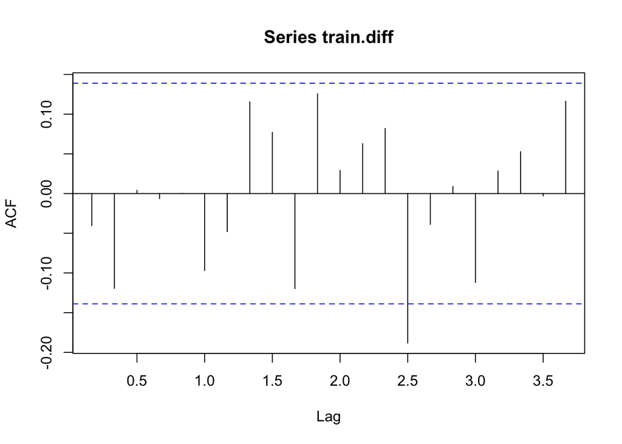

```r
acf_newtrain<-acf(train.diff)
```

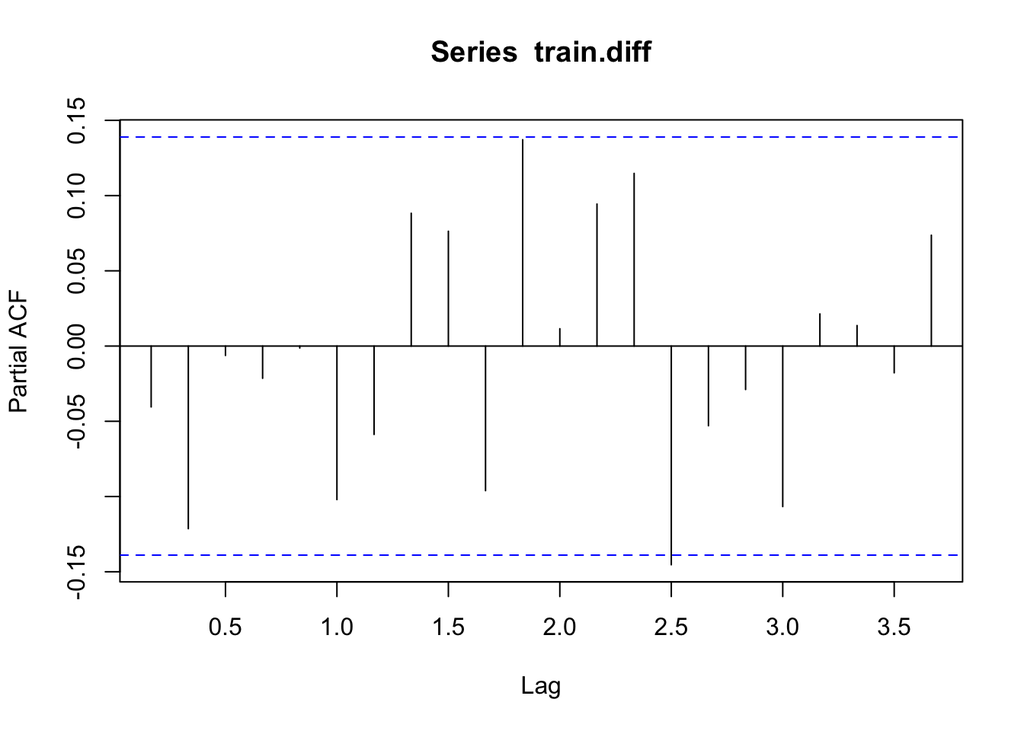

```r
pacf_newtrain <- pacf(train.diff)
```

## Uji ADF

```r
tseries::adf.test(train.diff)
```

```
##
##  Augmented Dickey-Fuller Test
##
## data:  train.diff
## Dickey-Fuller = -6.5201, Lag order = 5, p-value = 0.01
## alternative hypothesis: stationary
```

$H_0$ : Data tidak stasioner dalam rataan

$H_1$ : Data stasioner dalam rataan

Berdasarkan uji ADF tersebut, didapat p-value sebesar 0.01 yang lebih kecil dari taraf nyata 5% sehingga tolak $H_0$ atau data stasioner dalam rataan. Sehingga dalam hal ini ketidakstasioneran data sudah berhasil ditangani dan dapat dilanjutkan ke pemodelan.

## Plot EACF

```r
eacf(train.diff)
```

```
## AR/MA
##   0 1 2 3 4 5 6 7 8 9 10 11 12 13
## 0 o o o o o o o o o o o  o  o  o
## 1 x o o o o o o o o o o  o  o  o
## 2 o x o o o o o o o o o  o  o  o
## 3 x x o o o o o o o o o  o  o  o
## 4 o x o x o o o o o o o  o  o  o
## 5 o x o x x o o o o o o  o  o  o
## 6 x x o o o o o o o o o  o  o  o
## 7 x x x o x o x o o o o  o  o  o
```

# Pendugaan Parameter Model Tentatif

## ARIMA(0,1,3) atau MA(3)

```r
model1.da = Arima(train.diff,order=c(0,1,3),method = "ML")
summary(model1.da)
```

```
## Series: train.diff
## ARIMA(0,1,3)
##
## Coefficients:
##          ma1      ma2     ma3
##       -1.041  -0.0809  0.1219
## s.e.   0.073   0.1042  0.0732
##
## sigma^2 = 80.35:  log likelihood = -716.53
## AIC=1441.06   AICc=1441.27   BIC=1454.21
##
## Training set error measures:
##                      ME     RMSE      MAE     MPE     MAPE      MASE
## Training set 0.07636166 8.873291 5.699438 111.276 130.1724 0.6545191
##                      ACF1
## Training set -0.005010443
```

```r
coeftest(model1.da)
```

```
##
## z test of coefficients:
##
##      Estimate Std. Error  z value Pr(>|z|)
## ma1 -1.040993   0.073018 -14.2566  < 2e-16 ***
## ma2 -0.080866   0.104196  -0.7761  0.43769
## ma3  0.121859   0.073247   1.6637  0.09618 .
## ---
## Signif. codes:  0 '***' 0.001 '**' 0.01 '*' 0.05 '.' 0.1 ' ' 1
```

Pada ARIMA(0,1,3) didapatkan nilai AIC sebesar 1441.06 dan 1 dari 3 parameter signifikan.

## ARIMA(1,1,2) atau ARMA(1,2)

```r
model2.da = Arima(train.diff,order=c(1,1,2),method = "ML")
summary(model2.da)
```

```
## Series: train.diff
## ARIMA(1,1,2)
##
## Coefficients:
##           ar1      ma1      ma2
##       -0.8508  -0.1127  -0.8873
## s.e.   0.1630   0.1417   0.1415
##
## sigma^2 = 81.39:  log likelihood = -717.6
## AIC=1443.2   AICc=1443.41   BIC=1456.35
##
## Training set error measures:
##                     ME     RMSE     MAE      MPE    MAPE      MASE        ACF1
## Training set 0.0866031 8.930414 5.70019 102.4942 124.493 0.6546054 -0.06902285
```

```r
coeftest(model2.da)
```

```
##
## z test of coefficients:
##
##     Estimate Std. Error z value  Pr(>|z|)
## ar1 -0.85083    0.16305 -5.2182 1.807e-07 ***
## ma1 -0.11271    0.14167 -0.7956    0.4262
## ma2 -0.88729    0.14151 -6.2702 3.606e-10 ***
## ---
## Signif. codes:  0 '***' 0.001 '**' 0.01 '*' 0.05 '.' 0.1 ' ' 1
```

Pada ARIMA(1,1,2) didapatkan nilai AIC sebesar 1443.2 dan 2 dari 3 parameter signifikan

## ARIMA(2,1,3) atau ARMA(2,3)

```r
model3.da = Arima(train.diff,order=c(2,1,3),method = "ML")
summary(model3.da)
```

```
## Series: train.diff
## ARIMA(2,1,3)
##
## Coefficients:
##           ar1     ar2      ma1      ma2     ma3
##       -0.2692  0.3835  -0.7746  -0.7343  0.5089
## s.e.   0.3524  0.3228   0.3283   0.3192  0.3001
##
## sigma^2 = 80.95:  log likelihood = -716.29
## AIC=1444.59   AICc=1445.03   BIC=1464.32
##
## Training set error measures:
##                      ME     RMSE      MAE     MPE     MAPE      MASE
## Training set 0.06956145 8.860694 5.707946 107.781 131.1735 0.6554961
##                       ACF1
## Training set -0.0004821806
```

```r
coeftest(model3.da)
```

```
##
## z test of coefficients:
##
##     Estimate Std. Error z value Pr(>|z|)
## ar1 -0.26922    0.35242 -0.7639  0.44492
## ar2  0.38352    0.32281  1.1881  0.23480
## ma1 -0.77463    0.32830 -2.3595  0.01830 *
## ma2 -0.73429    0.31917 -2.3007  0.02141 *
## ma3  0.50892    0.30009  1.6959  0.08990 .
## ---
## Signif. codes:  0 '***' 0.001 '**' 0.01 '*' 0.05 '.' 0.1 ' ' 1
```

Pada ARIMA(2,1,3) didapatkan nilai AIC sebesar 1444.59 dan 2 dari 5 parameter signifikan.

## ARIMA(2,1,5) atau ARMA(2,5)

```r
model4.da = Arima(train.diff,order=c(2,1,5),method = "ML")
summary(model4.da)
```

```
## Series: train.diff
## ARIMA(2,1,5)
##
## Coefficients:
##           ar1      ar2      ma1      ma2      ma3     ma4     ma5
##       -1.0097  -0.8854  -0.0086  -0.2231  -0.9482  0.0007  0.1792
## s.e.   0.0755   0.0579   0.1002   0.0998   0.0456  0.0753  0.0734
##
## sigma^2 = 78.93:  log likelihood = -713.07
## AIC=1442.13   AICc=1442.89   BIC=1468.44
##
## Training set error measures:
##                      ME     RMSE      MAE      MPE     MAPE      MASE
## Training set 0.06852112 8.703939 5.633749 105.8978 144.8166 0.6469754
##                      ACF1
## Training set -0.007388208
```

```r
coeftest(model4.da)
```

```
##
## z test of coefficients:
##
##        Estimate  Std. Error  z value Pr(>|z|)
## ar1 -1.00968760  0.07546158 -13.3802  < 2e-16 ***
## ar2 -0.88535558  0.05786191 -15.3012  < 2e-16 ***
## ma1 -0.00860490  0.10020665  -0.0859  0.93157
## ma2 -0.22313751  0.09975340  -2.2369  0.02529 *
## ma3 -0.94818194  0.04556392 -20.8099  < 2e-16 ***
## ma4  0.00069136  0.07532120   0.0092  0.99268
## ma5  0.17923556  0.07342193   2.4412  0.01464 *
## ---
## Signif. codes:  0 '***' 0.001 '**' 0.01 '*' 0.05 '.' 0.1 ' ' 1
```

Pada ARIMA(2,1,5) didapatkan nilai AIC sebesar 1442.13 dan 5 dari 7 parameter signifikan

```r
model5.da = Arima(train.diff,order=c(3,1,4),method = "ML")
summary(model5.da)
```

```
## Series: train.diff
## ARIMA(3,1,4)
##
## Coefficients:
##           ar1      ar2      ar3      ma1     ma2     ma3      ma4
##       -0.5623  -0.6573  -0.8772  -0.4575  0.0769  0.2979  -0.9171
## s.e.   0.1338   0.0486   0.1430   0.1098  0.1371  0.1373   0.1200
##
## sigma^2 = 79.55:  log likelihood = -714.02
## AIC=1444.04   AICc=1444.81   BIC=1470.35
##
## Training set error measures:
##                     ME     RMSE      MAE      MPE     MAPE      MASE
## Training set 0.0913905 8.738065 5.542058 88.50534 141.9356 0.6364457
##                     ACF1
## Training set -0.02335086
```

```r
coeftest(model5.da)
```

```
##
## z test of coefficients:
##
##      Estimate Std. Error  z value  Pr(>|z|)
## ar1 -0.562343   0.133786  -4.2033 2.631e-05 ***
## ar2 -0.657349   0.048571 -13.5337 < 2.2e-16 ***
## ar3 -0.877228   0.143040  -6.1327 8.638e-10 ***
## ma1 -0.457527   0.109767  -4.1682 3.071e-05 ***
## ma2  0.076873   0.137136   0.5606   0.57510
## ma3  0.297854   0.137280   2.1697   0.03003 *
## ma4 -0.917143   0.120011  -7.6422 2.136e-14 ***
## ---
## Signif. codes:  0 '***' 0.001 '**' 0.01 '*' 0.05 '.' 0.1 ' ' 1
```

## ARIMA(6,1,7) atau ARMA(6,7)

```r
model6.da = Arima(train.diff,order=c(6,1,7),method = "ML")
summary(model6.da)
```

```
## Series: train.diff
## ARIMA(6,1,7)
##
## Coefficients:
##          ar1     ar2      ar3     ar4     ar5      ar6      ma1      ma2
##       0.1382  0.4889  -0.7858  0.5406  0.1981  -0.8932  -1.2396  -0.3391
## s.e.  0.0361  0.0322   0.0434  0.0347  0.0309   0.0507   0.0670   0.0869
##          ma3      ma4     ma5     ma6      ma7
##       1.4189  -1.4528  0.4025  1.1827  -0.9724
## s.e.  0.0672   0.0767  0.0496  0.0391   0.0615
##
## sigma^2 = 75.91:  log likelihood = -709.13
## AIC=1446.26   AICc=1448.55   BIC=1492.29
##
## Training set error measures:
##                      ME     RMSE     MAE      MPE     MAPE      MASE       ACF1
## Training set 0.09702088 8.400644 5.29732 77.48346 155.6647 0.6083401 0.01281639
```

```r
coeftest(model6.da)
```

```
##
## z test of coefficients:
##
##      Estimate Std. Error  z value  Pr(>|z|)
## ar1  0.138249   0.036126   3.8268 0.0001298 ***
## ar2  0.488911   0.032207  15.1802 < 2.2e-16 ***
## ar3 -0.785779   0.043432 -18.0921 < 2.2e-16 ***
## ar4  0.540611   0.034742  15.5609 < 2.2e-16 ***
## ar5  0.198118   0.030862   6.4195 1.367e-10 ***
## ar6 -0.893180   0.050723 -17.6090 < 2.2e-16 ***
## ma1 -1.239618   0.066971 -18.5098 < 2.2e-16 ***
## ma2 -0.339072   0.086883  -3.9026 9.515e-05 ***
## ma3  1.418903   0.067167  21.1249 < 2.2e-16 ***
## ma4 -1.452847   0.076705 -18.9407 < 2.2e-16 ***
## ma5  0.402482   0.049612   8.1126 4.957e-16 ***
## ma6  1.182662   0.039068  30.2722 < 2.2e-16 ***
## ma7 -0.972373   0.061495 -15.8123 < 2.2e-16 ***
## ---
## Signif. codes:  0 '***' 0.001 '**' 0.01 '*' 0.05 '.' 0.1 ' ' 1
```

Pada ARIMA(6,1,7) didapatkan nilai AIC sebesar 1446.26 dan 13 dari 13 parameter signifikan

Berdasarkan pendugaan parameter di atas, nilai AIC terkecil dimiliki oleh model ARIMA(0,1,3) tetapi tidak seluruhnya signifikan. Parameter yang seluruhnya signfikan dimiliki oleh model ARIMA(6,1,7) dengan AIC 1446.25. Sehingga model yang dipilih adalah model ARIMA(6,1,7).